# 2.2 Probability Mass Functions

## Definition

The **probability mass function (pmf)** of a discrete random variable $X$ is a function $p_X: \mathbb{R} \to [0,1]$ defined by:
$$p_X(x) = P(X = x),\quad x\in R_X,$$
where $R_X=\text{range}(X)$ is the set of values the random variable can take.

The pmf of a discrete random variable defines the **probability distribution** of a random variable.

- We frequently assign names to common probability distributions.

## Range of a random variable

The range of a discrete random variable $X$ is defined as
$$R_X = \{x\in\mathbb{R}:P(X=x)>0\}.$$

When $X$ is discrete, then $R_X$ contains a countable number of elements.

## Range versus support

The **support** of a discrete random variable is sometimes used synonymously with the range of $X$ (Casella and Berger 2002; Blitzstein and Hwang 2019; Reich and Ghosh 2019).

Other [resources](http://www.probability.net/WEBregularity.pdf#support) define the support of $X$, $S_X$, as the smallest closed set such that
$$\sum_{x\in S_X} p_X(x) = 1.$$

Under this second definition, the range and support will be the same for discrete random variables but can differ for continuous random variables.

## Notation

- Uppercase $X$ will denote a random variable.
- Lowercase $x$ will denote a specific numeric value.

## Calculation of a discrete pmf

For each possible value $x$ of $X$:

1. Collect all the possible outcomes that give rise to the event $\{X = x\}$.
2. Add their probabilities to obtain $p_X(x)$.

## Visualization of pmf calculation

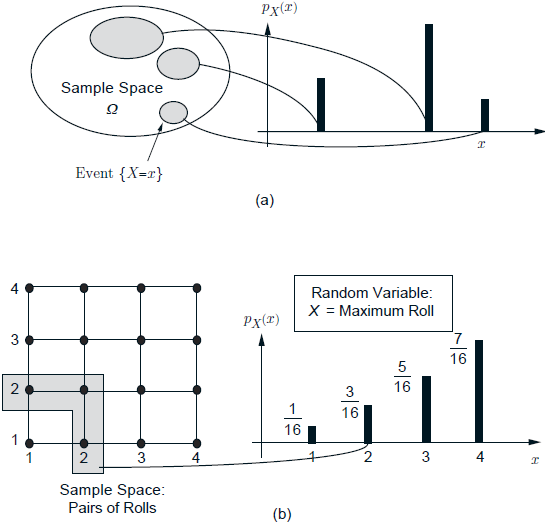

Calculating a pmf

## Simple example

Suppose we toss a fair coin twice in a row and count the number of heads.

$$p_X(x) =
\begin{cases}
\phantom{\frac{1}{4}} & \text{if } x = 0 \\
\phantom{\frac{1}{2}} & \text{if } x = 1 \\
\phantom{\frac{1}{4}} & \text{if } x = 2.
\end{cases}$$

## Properties of pmfs

The pmf of a random variable $X$, $p_X(x)$, satisfies the following properties:

- $p_X(x) \geq 0$ for all $x$
- $\sum_{x \in R_X} p_X(x) = 1$, where $R_X$ is the range of $X$.
- If $A\subset R_X$, then $P(A) = \sum_{x \in A} p_X(x)$.

E.g., continuing our simple coin flipping example,
$$P(X > 0) = p_X(1) + p_X(2) = \frac{1}{2} + \frac{1}{4} = \frac{3}{4}.$$

## The Bernoulli random variable

A Bernoulli random variable models a single trial that has only two possible outcomes: success or failure.

- A success occurs with probability $p\in [0,1]$ and is assigned the value 1.
- A failure occurs with probability $1-p$ and is assigned the value 0.

## The Bernoulli random variable defined

Let $X$ be a Bernoulli random variable such that the probability of a success is $p \in [0,1]$.

- Then $X\sim \text{Bernoulli}(p)$ (read as $X$ is distributed as Bernoulli $p$).

The pmf of $X$ is:
$$p_X(x) =
\begin{cases}
& \text{if } x = 1 \\
\phantom{1-p} & \text{if } x = 0 \\
& \text{otherwise}.
\end{cases}$$

$R_X:$

## Bernoulli examples

- Website clicks: A user either clicks on an ad (success) or doesn’t (failure).
- Medical diagnosis: A test either detects a disease (positive result) or not (negative result).
- Email spam filter: An income email is marked as spam (success) or not (failure).
- Sensor activation: A motion sensor either detects movement (success) or doesn’t (failure) in a given time frame.

## Independent and identically distributed

We often assume that random variables are **independent and identically distributed** (i.i.d.).

i.i.d. random variables are defined by two characteristics:

1. All of the random variables are independent.
   - Conceptually, the value of one random variable has no impact on the others (and so on).
2. Each of the random variables has the exact same probability distribution.

## The Binomial random variable

A Binomial random variable models the number of successes in a sequence of $n$ i.i.d. $\text{Bernoulli}(p)$ trials.

If $X\sim\text{Binomial}(n, p)$, then the pmf is
$$p_X(k) = \binom{n}{k} p^k (1 - p)^{n - k}, \quad \text{for } k = 0, 1, 2, \dots, n.$$

$R_X:$

## Visualizing a Binomial pmf

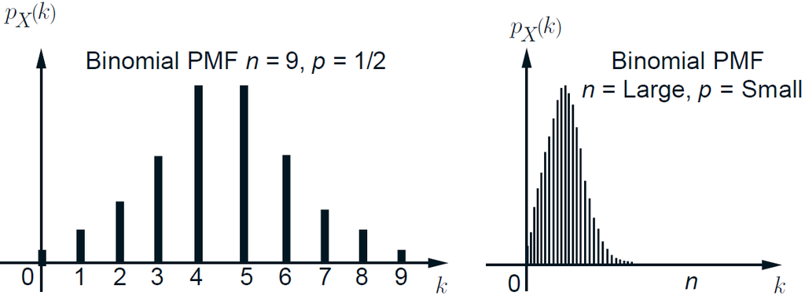

The pmf of a Binomial random variable

## Binomial examples

Product defects: counting the number of defective items in a batch of manufactured goods.

Email campaigns: counting how many recipients open an email out of a fixed number sent.

Vaccination cffectiveness: out of 100 vaccinated individuals, how many avoid infection?

Memory tests: how many words a subject recalls correctly out of a list.

## Computing a binomial probability

Only 5% of a lot of 20 electrical fuses are supposed to be defective. What is the probability that at least four defective fuses are observed?

## The Geometric random variable

A Geometric random variable counts the number of i.i.d. $\text{Bernoulli}(p)$ trials until the first success.

If $X\sim \text{Geometric}(p)$, then the pmf is
$$p_X(x) = (1 - p)^{x - 1} p, \quad x = 1, 2, 3, \dots$$

$R_X:$

## Visualizing a Geometric pmf

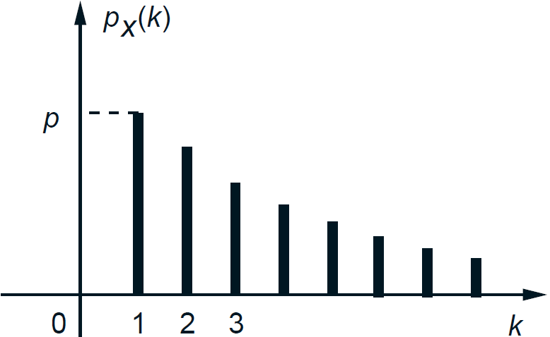

The pmf of a Geometric random variable

## Geometric examples

How many calls must a call center agent make until they reach a customer who answers?

How many items must we inspect until we find a defective one?

How many free throws must a person take until they make one?

## Geometric computation

A call center agent must keep making calls until they reach a customer who answers. The probability of a customer answering is 0.10. What is the probability that the agent needs to make at least 20 calls?

## The Poisson distribution

A **Poisson random variable** models the number of events occurring in a fixed interval of time or space, assuming events occur independently and at a constant average rate, $\lambda > 0$.

If $X\sim \text{Poisson}(\lambda)$, then the pmf is
$$p_X(x) = \frac{\lambda^x e^{-\lambda}}{x!}, \quad x = 0, 1, 2, \dots$$

$R_X:$

## Visualizing a Poisson pmf

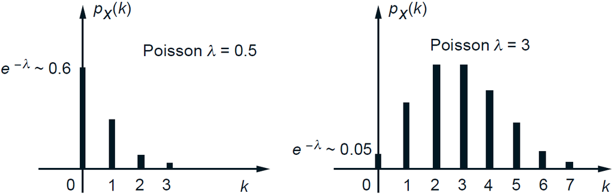

The pmf of a Poisson random variable

## Poisson examples

Emails received: the number of emails received per hour, with an average rate of $\lambda = 5$.

Website hits: the number of website in a minute if the average is 50 hits per minute.

Accidental deaths by horse kick: Ladislaus Bortkiewicz analyzed the number of soldiers in the Prussian army killed by horse kicks. The average was 0.61 deaths per corps per year, and the distribution of deaths followed a Poisson pattern.

## Poisson computation

A small bakery receives an average of 4 online orders per hour. They can fulfill 8 online orders in an hour, if necessary. What is the probability that they receive more than 8 orders in an hour?

## The Negative Binomial distribution

The Negative Binomial distribution models the total number of trials needed to achieve $r$ successes in a sequence of i.i.d. $\text{Bernoulli}(p)$ trials.

If $X \sim \text{NB}(r, p)$, then the pmf is
$$p_X(k) = \binom{k - 1}{r - 1} p^r (1 - p)^{k - r}, \quad x = r, r+1, \dots.$$

$R_X:$

Note: there are multiple characterizations, e.g., the number failures until the $r$th success.

## Visualizing a Negative Binomial pmf

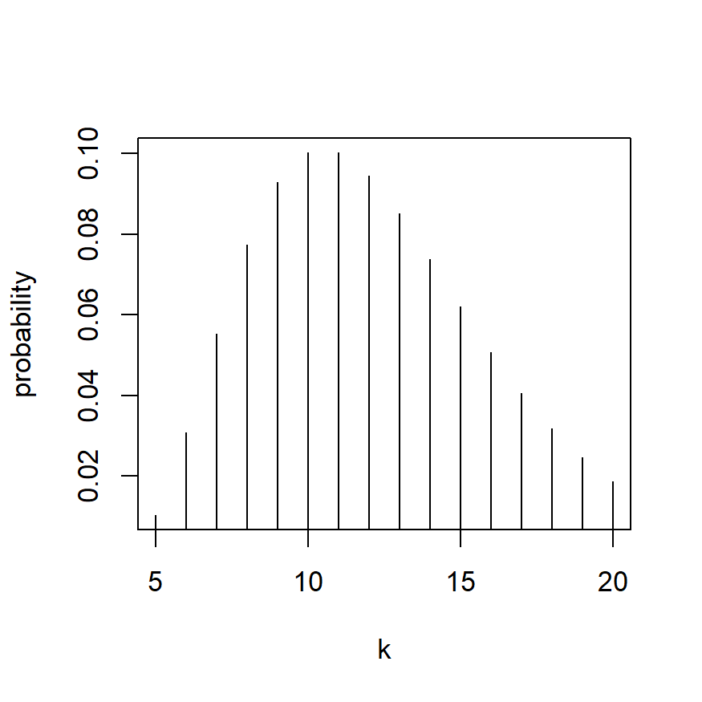

The pmf of a Negative Binomial random variable

## Negative Binomial examples

Modeling disease outbreaks: model the number of cases until a certain number of recoveries or deaths occur.

Click-through rates: used in online advertising to model the number of ad impressions until a certain number of clicks occur.

Failure analysis: model the number of trials until a component fails a set number of times.

## Negative Binomial computation

Suppose a basketball player has a 60% chance of making a free throw. What is the probability that it takes at least 7 shots to make 3 successful free throws?

## References

Blitzstein, Joseph K, and Jessica Hwang. 2019. *Introduction to Probability, 2nd Edition*. Chapman; Hall/CRC.

Casella, George, and Roger Berger. 2002. *Statistical Inference, 2nd Edition*. Chapman; Hall/CRC.

Reich, Brian J, and Sujit K Ghosh. 2019. *Bayesian Statistical Methods*. Chapman; Hall/CRC.